# Concrete Compressive Strength

```python
import pandas as pd
import numpy as np
from scipy import stats
import matplotlib.pyplot as plt
import seaborn as sns
%matplotlib inline
from scipy.stats import zscore
from sklearn.model_selection import train_test_split
from sklearn import model_selection
from sklearn.model_selection import KFold
from sklearn.model_selection import cross_val_score
from sklearn import metrics
from sklearn.model_selection import cross_val_score
from sklearn.metrics import confusion_matrix, accuracy_score

import sys
import warnings
if not sys.warnoptions:
    warnings.simplefilter("ignore")
```

```python
#Loading the dataset and storing in dataframe
concrete_df = pd.read_csv('concrete.csv')
```

```python
concrete_df.head()
```

|  | cement | slag | ash | water | superplastic | coarseagg | fineagg | age | strength |
| --- | --- | --- | --- | --- | --- | --- | --- | --- | --- |
| 0 | 141.3 | 212.0 | 0.0 | 203.5 | 0.0 | 971.8 | 748.5 | 28 | 29.89 |
| 1 | 168.9 | 42.2 | 124.3 | 158.3 | 10.8 | 1080.8 | 796.2 | 14 | 23.51 |
| 2 | 250.0 | 0.0 | 95.7 | 187.4 | 5.5 | 956.9 | 861.2 | 28 | 29.22 |
| 3 | 266.0 | 114.0 | 0.0 | 228.0 | 0.0 | 932.0 | 670.0 | 28 | 45.85 |
| 4 | 154.8 | 183.4 | 0.0 | 193.3 | 9.1 | 1047.4 | 696.7 | 28 | 18.29 |

```python
#Checking Width and Depth of the Data
print("Number of rows    :",concrete_df.shape[0])
print("Number of columns :",concrete_df.shape[1])
```

```
Number of rows    : 1030
Number of columns : 9
```

```python
#Finding Datatypes of Each Attribute in the data
concrete_df.dtypes
```

```
cement          float64
slag            float64
ash             float64
water           float64
superplastic    float64
coarseagg       float64
fineagg         float64
age               int64
strength        float64
dtype: object
```

```python
#Checking and Analysing Data Distribution
concrete_df.describe().transpose()
```

|  | count | mean | std | min | 25% | 50% | 75% | max |
| --- | --- | --- | --- | --- | --- | --- | --- | --- |
| cement | 1030.0 | 281.167864 | 104.506364 | 102.00 | 192.375 | 272.900 | 350.000 | 540.0 |
| slag | 1030.0 | 73.895825 | 86.279342 | 0.00 | 0.000 | 22.000 | 142.950 | 359.4 |
| ash | 1030.0 | 54.188350 | 63.997004 | 0.00 | 0.000 | 0.000 | 118.300 | 200.1 |
| water | 1030.0 | 181.567282 | 21.354219 | 121.80 | 164.900 | 185.000 | 192.000 | 247.0 |
| superplastic | 1030.0 | 6.204660 | 5.973841 | 0.00 | 0.000 | 6.400 | 10.200 | 32.2 |
| coarseagg | 1030.0 | 972.918932 | 77.753954 | 801.00 | 932.000 | 968.000 | 1029.400 | 1145.0 |
| fineagg | 1030.0 | 773.580485 | 80.175980 | 594.00 | 730.950 | 779.500 | 824.000 | 992.6 |
| age | 1030.0 | 45.662136 | 63.169912 | 1.00 | 7.000 | 28.000 | 56.000 | 365.0 |
| strength | 1030.0 | 35.817961 | 16.705742 | 2.33 | 23.710 | 34.445 | 46.135 | 82.6 |

```python
#Checking for NUll Values in the dataframe..
concrete_df.isnull().any()
```

```
cement          False
slag            False
ash             False
water           False
superplastic    False
coarseagg       False
fineagg         False
age             False
strength        False
dtype: bool
```

There are no nulls, but the dataset contains zero values in various attributes and they need to be treated.

```python
clean_concrete = concrete_df.copy()
#clean_concrete = clean_concrete.replace(to_replace = 0, value = clean_concrete.median())
#lean_concrete.head(10)
```

```python
#Checking and Analysing Data Distribution
clean_concrete.describe().transpose()
```

|  | count | mean | std | min | 25% | 50% | 75% | max |
| --- | --- | --- | --- | --- | --- | --- | --- | --- |
| cement | 1030.0 | 281.167864 | 104.506364 | 102.00 | 192.375 | 272.900 | 350.000 | 540.0 |
| slag | 1030.0 | 73.895825 | 86.279342 | 0.00 | 0.000 | 22.000 | 142.950 | 359.4 |
| ash | 1030.0 | 54.188350 | 63.997004 | 0.00 | 0.000 | 0.000 | 118.300 | 200.1 |
| water | 1030.0 | 181.567282 | 21.354219 | 121.80 | 164.900 | 185.000 | 192.000 | 247.0 |
| superplastic | 1030.0 | 6.204660 | 5.973841 | 0.00 | 0.000 | 6.400 | 10.200 | 32.2 |
| coarseagg | 1030.0 | 972.918932 | 77.753954 | 801.00 | 932.000 | 968.000 | 1029.400 | 1145.0 |
| fineagg | 1030.0 | 773.580485 | 80.175980 | 594.00 | 730.950 | 779.500 | 824.000 | 992.6 |
| age | 1030.0 | 45.662136 | 63.169912 | 1.00 | 7.000 | 28.000 | 56.000 | 365.0 |
| strength | 1030.0 | 35.817961 | 16.705742 | 2.33 | 23.710 | 34.445 | 46.135 | 82.6 |

###### OUtliers Treatment:

```
              No. of Outliers  Percentage Outliers
cement                      0                 0.00
slag                        2                 0.19
ash                         0                 0.00
water                       9                 0.87
superplastic               10                 0.97
coarseagg                   0                 0.00
fineagg                     5                 0.49
age                        59                 5.73
strength                    4                 0.39
```

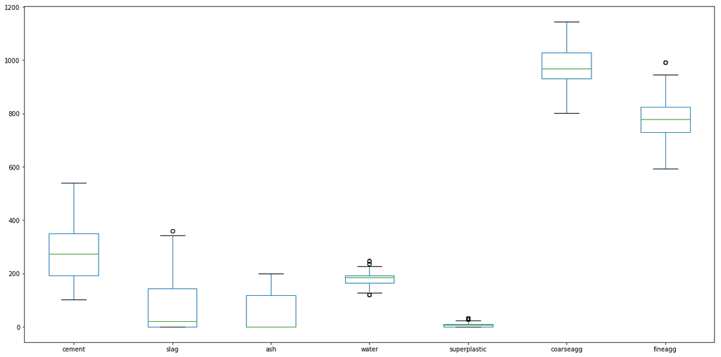

```python
#Finding Outliers
q1 = clean_concrete.quantile(0.25)
q3 = clean_concrete.quantile(0.75)
IQR = q3-q1
cwo = ((clean_concrete.iloc[:] < (q1-1.5 * IQR)) | (clean_concrete.iloc[:] > (q3+1.5*IQR))).sum(axis = 0)
outlier_df = pd.DataFrame(cwo, index = clean_concrete.columns, columns = ['No. of Outliers'])
outlier_df['Percentage Outliers'] = round(outlier_df['No. of Outliers'] * 100 / len(concrete_df), 2)
print(outlier_df)

# Plotting the Columns with Outliers
plt.figure(figsize = (20, 10))
boxplot = clean_concrete.boxplot(column = ['cement', 'slag', 'ash', 'water', 'superplastic', 'coarseagg', 'fineagg'], grid = False)
```

```python
# Handling Outliers using IQR method
clean_concrete2 = clean_concrete.copy()
def handle_outlier(df_in, col_name):
    q1 = df_in[col_name].quantile(0.25)
    q3 = df_in[col_name].quantile(0.75)
    iqr = q3-q1 #Interquartile range
    fence_low  = q1-1.5*iqr
    fence_high = q3+1.5*iqr
    df_in.loc[df_in[col_name] > fence_high, col_name] = df_in[col_name].median()
    df_in.loc[(df_in[col_name] < fence_low), col_name] = df_in[col_name].median()
    return df_in
clean_concrete2 = handle_outlier(clean_concrete2, 'cement')
clean_concrete2 = handle_outlier(clean_concrete2, 'slag')
clean_concrete2 = handle_outlier(clean_concrete2, 'ash')
clean_concrete2 = handle_outlier(clean_concrete2, 'water')
clean_concrete2 = handle_outlier(clean_concrete2, 'superplastic')
clean_concrete2 = handle_outlier(clean_concrete2, 'coarseagg')
clean_concrete2 = handle_outlier(clean_concrete2, 'fineagg')
clean_concrete2['age'] = clean_concrete2['age']
clean_concrete2['strength'] = clean_concrete2['strength']
```

###### Plotting Features' correlation and Features-Target Correlation

```python
feature = clean_concrete2.drop(['strength'], axis = 1)
target = clean_concrete2["strength"]
```

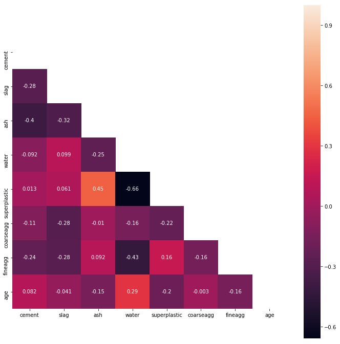

```python
#Plotting Features HeatMap
corr = feature.corr()

mask = np.zeros_like(corr)
mask[np.triu_indices_from(mask)] = True

plt.figure(figsize = (12, 12))
sns.heatmap(corr, mask = mask,annot = True, square = True)
```

superplastic and ash are a bit correlated. These attributes' distribution needs to be considered in bivariate analysis. It can also be observed that water and supaerplastic are inversely related

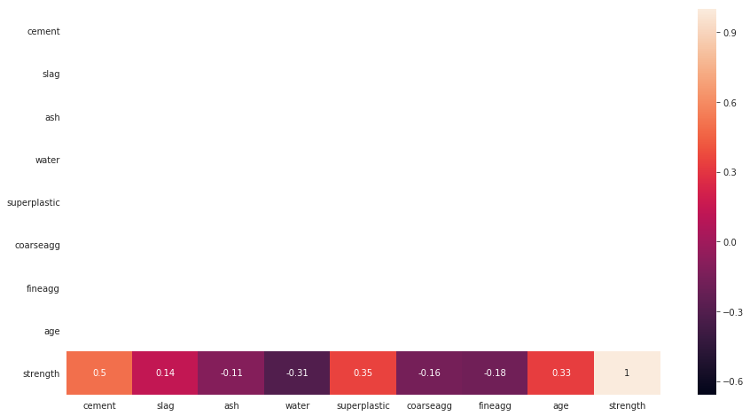

```python
#Plotting Features- Target HeatMap
feature_target_corr = feature.join(target).corr()

mask = np.zeros((9, 9))
mask[:8, :] = 1

plt.figure(figsize=(15, 8))
with sns.axes_style("white"):
    sns.heatmap(feature_target_corr, annot=True, mask = mask)
```

Cement, Superplastic and age are the attributes which fairly influence the the Concrete's Compressive Strength.

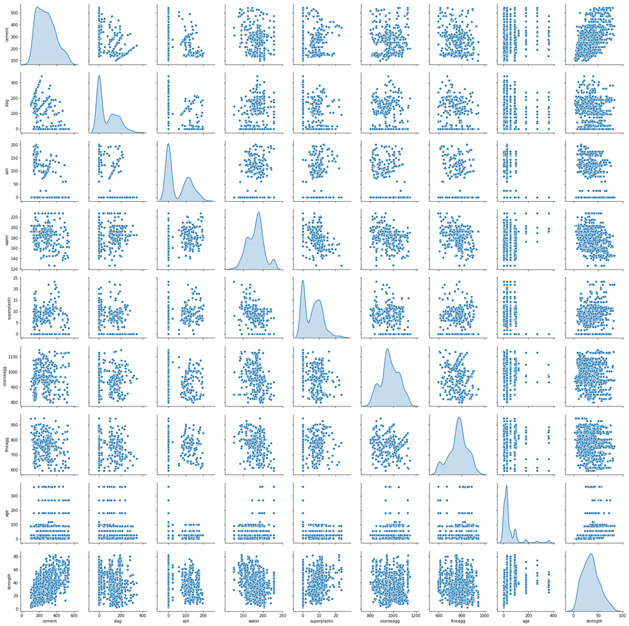

```python
sns.pairplot(clean_concrete2, diag_kind='kde')
```

[output not shown]

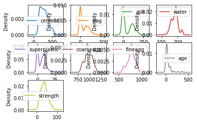

```python
clean_concrete2.plot(kind = 'density', subplots = True, layout = (3,4), sharex = False, sharey = False)
```

None of the features have a Guassian Distribution. All of them have a positive skew except 'water' and 'fineagg', which have negative skews

##### Analysing Each Attribute Distribution:

##### 1. Cement: Cement is an Age Bonding agent or Glue of the concrete which keeps all the different elements of concrete together. Cement also helps in giving strength to the mix

```python
clean_concrete2.cement.describe().transpose()
```

```
count    1030.000000
mean      281.167864
std       104.506364
min       102.000000
25%       192.375000
50%       272.900000
75%       350.000000
max       540.000000
Name: cement, dtype: float64
```

###### 2. slag: Blast Furnace Slag is a by-product of iron manufacturing which when added to concrete improves its properties such as workability, strength and durability

```python
clean_concrete2.slag.describe().transpose()
```

```
count    1030.000000
mean       73.240680
std        85.384419
min         0.000000
25%         0.000000
50%        22.000000
75%       142.725000
max       342.100000
Name: slag, dtype: float64
```

###### 3. ash: It improves strength and durability of hard concrete.

```python
clean_concrete2.ash.describe().transpose()
```

```
count    1030.000000
mean       54.188350
std        63.997004
min         0.000000
25%         0.000000
50%         0.000000
75%       118.300000
max       200.100000
Name: ash, dtype: float64
```

##### 4. Water: Key ingredient which when moxed with cement, it forms a paste that binds the aggregate together. Water causes the hardening of concrete through a process of hydration.

```python
clean_concrete2.water.describe().transpose()
```

```
count    1030.000000
mean      181.653107
std        20.603205
min       126.600000
25%       164.900000
50%       185.000000
75%       192.000000
max       228.000000
Name: water, dtype: float64
```

###### 5. superplastic: Superplasticizer is used when flyash is used in cement. Increases strength of concrete.

```python
clean_concrete2.superplastic.describe().transpose()
```

```
count    1030.000000
mean        5.973592
std         5.477165
min         0.000000
25%         0.000000
50%         6.400000
75%        10.075000
max        23.400000
Name: superplastic, dtype: float64
```

###### 6. coarseagg: Innert granular materials. Provides mass and strength to concrete.

```python
clean_concrete2.coarseagg.describe().transpose()
```

```
count    1030.000000
mean      972.918932
std        77.753954
min       801.000000
25%       932.000000
50%       968.000000
75%      1029.400000
max      1145.000000
Name: coarseagg, dtype: float64
```

```python
clean_concrete2.fineagg.describe().transpose()
```

```
count    1030.000000
mean      772.546019
std        78.703232
min       594.000000
25%       730.950000
50%       779.400000
75%       822.200000
max       945.000000
Name: fineagg, dtype: float64
```

###### Age: Age of Concrete is the time elapsed since it was poured in place and left to set.

```python
clean_concrete2.age.describe().transpose()
```

```
count    1030.000000
mean       45.662136
std        63.169912
min         1.000000
25%         7.000000
50%        28.000000
75%        56.000000
max       365.000000
Name: age, dtype: float64
```

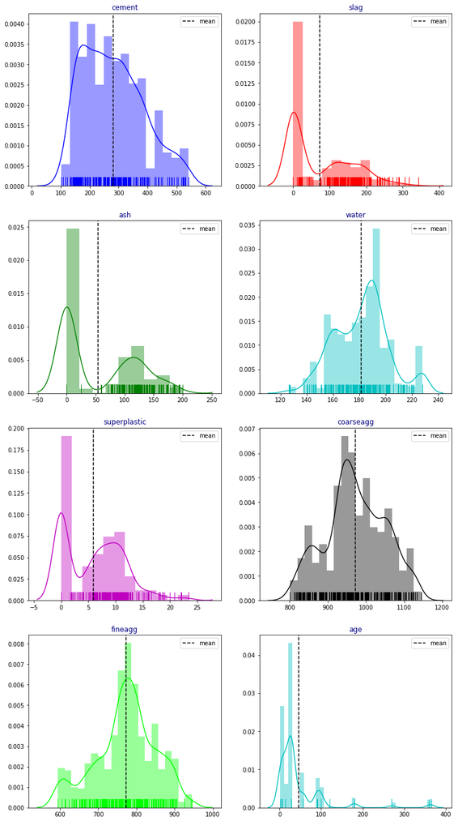

```python
import itertools
cols = [i for i in clean_concrete2.columns if i not in 'strength']
length = len(cols)
cs = ["b", "r", "g", "c", "m", "k", "lime", "c"]
fig = plt.figure(figsize = (13, 25))

for i, j, k in itertools.zip_longest(cols, range(length), cs):
    plt.subplot(4,2,j+1)
    ax = sns.distplot(clean_concrete2[i], color = k, rug = True)
    ax.set_facecolor("w")
    plt.axvline(clean_concrete2[i].mean(),linestyle = "dashed", label = "mean", color = "k")
    plt.legend(loc = "best")
    plt.title(i, color = "navy")
    plt.xlabel(" ")
```

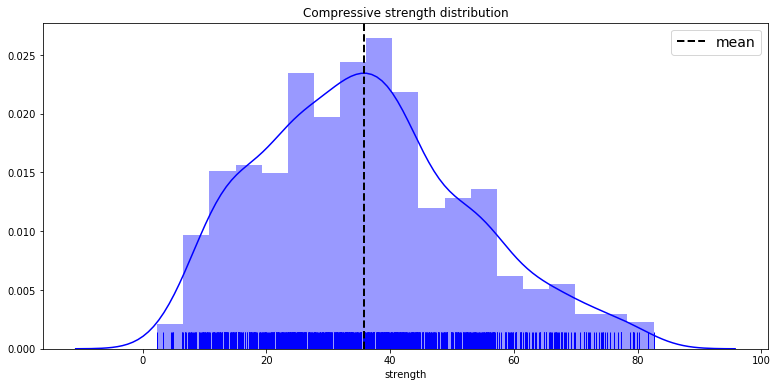

```python
plt.figure(figsize=(13,6))
sns.distplot(clean_concrete2["strength"], color = "b", rug = True)
plt.axvline(clean_concrete2["strength"].mean(),
            linestyle = "dashed", color = "k",
            label = 'mean', linewidth = 2)
plt.legend(loc = "best", prop = {"size" : 14})
plt.title("Compressive strength distribution")
plt.show()
```

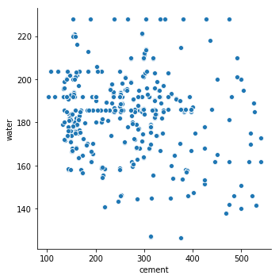

```python
sns.relplot( x = "cement", y = "water", data = clean_concrete2)
```

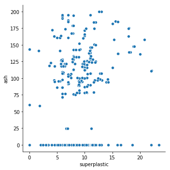

```python
sns.relplot( x = "superplastic", y = "ash", data = clean_concrete2)
```

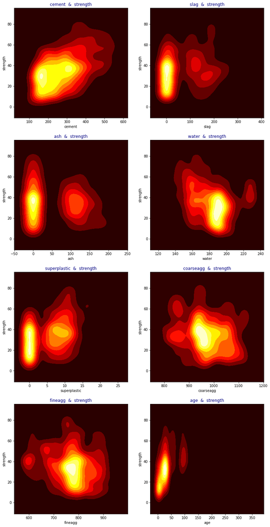

```python
cols = [i for i in clean_concrete2.columns if i not in 'strength']
length = len(cols)

plt.figure(figsize=(13,27))
for i,j in itertools.zip_longest(cols,range(length)):
    plt.subplot(4,2,j+1)
    sns.kdeplot(clean_concrete2[i],
                clean_concrete2["strength"],
                cmap="hot",
                shade=True)
    plt.title(i+"  &  strength", color = "navy")
```

[figure not shown]

```python
from mpl_toolkits.mplot3d import Axes3D

fig = plt.figure(figsize=(14,11))

ax  = fig.gca(projection = "3d")
#plt.subplot(111,projection = "3d")

plot =  ax.scatter(clean_concrete2["cement"],
           clean_concrete2["strength"],
           clean_concrete2["superplastic"],
           linewidth=1,edgecolor ="k",
           c = clean_concrete2["age"],s=100,cmap="cool")

ax.set_xlabel("cement")
ax.set_ylabel("compressive_strength")
ax.set_zlabel("super_plasticizer")

lab = fig.colorbar(plot,shrink=.5,aspect=5)
lab.set_label("AGE",fontsize = 15)

plt.title("3D plot for cement,compressive strength and super plasticizer",color="navy")
plt.show()
```

##### Dealing with age attibute: Grouping values to obtain better results

```python
new_concrete = clean_concrete2.copy()
#Binning days to months
def label(clean_concrete2):
    if clean_concrete2["age"] <= 30:
        return 1
    if clean_concrete2["age"] > 30 and clean_concrete2["age"] <= 60 :
        return 2
    if clean_concrete2["age"] > 60 and clean_concrete2["age"] <= 90 :
        return 3
    if clean_concrete2["age"] > 90 and clean_concrete2["age"] <= 120 :
        return 4
    if clean_concrete2["age"] > 120 and clean_concrete2["age"] <= 150 :
        return 5
    if clean_concrete2["age"] > 150 and clean_concrete2["age"] <= 180 :
        return 6
    if clean_concrete2["age"] > 180 and clean_concrete2["age"] <= 210 :
        return 7
    if clean_concrete2["age"] > 210 and clean_concrete2["age"] <= 240 :
        return 8
    if clean_concrete2["age"] > 240 and clean_concrete2["age"] <= 270 :
        return 9
    if clean_concrete2["age"] > 270 and clean_concrete2["age"] <= 300 :
        return 10
    if clean_concrete2["age"] > 300 and clean_concrete2["age"] <= 330 :
        return 11
    if clean_concrete2["age"] > 330 :
        return 12
new_concrete["age_months"] = clean_concrete2.apply(lambda clean_concrete2:label(clean_concrete2) , axis=1)
new_concrete.drop(['age'], axis = 1)
```

|  | cement | slag | ash | water | superplastic | coarseagg | fineagg | strength | age_months |
| --- | --- | --- | --- | --- | --- | --- | --- | --- | --- |
| 0 | 141.3 | 212.0 | 0.0 | 203.5 | 0.0 | 971.8 | 748.5 | 29.89 | 1 |
| 1 | 168.9 | 42.2 | 124.3 | 158.3 | 10.8 | 1080.8 | 796.2 | 23.51 | 1 |
| 2 | 250.0 | 0.0 | 95.7 | 187.4 | 5.5 | 956.9 | 861.2 | 29.22 | 1 |
| 3 | 266.0 | 114.0 | 0.0 | 228.0 | 0.0 | 932.0 | 670.0 | 45.85 | 1 |
| 4 | 154.8 | 183.4 | 0.0 | 193.3 | 9.1 | 1047.4 | 696.7 | 18.29 | 1 |
| 5 | 255.0 | 0.0 | 0.0 | 192.0 | 0.0 | 889.8 | 945.0 | 21.86 | 3 |
| 6 | 166.8 | 250.2 | 0.0 | 203.5 | 0.0 | 975.6 | 692.6 | 15.75 | 1 |
| 7 | 251.4 | 0.0 | 118.3 | 188.5 | 6.4 | 1028.4 | 757.7 | 36.64 | 2 |
| 8 | 296.0 | 0.0 | 0.0 | 192.0 | 0.0 | 1085.0 | 765.0 | 21.65 | 1 |
| 9 | 155.0 | 184.0 | 143.0 | 194.0 | 9.0 | 880.0 | 699.0 | 28.99 | 1 |
| 10 | 151.8 | 178.1 | 138.7 | 167.5 | 18.3 | 944.0 | 694.6 | 36.35 | 1 |
| 11 | 173.0 | 116.0 | 0.0 | 192.0 | 0.0 | 946.8 | 856.8 | 6.94 | 1 |
| 12 | 385.0 | 0.0 | 0.0 | 186.0 | 0.0 | 966.0 | 763.0 | 27.92 | 1 |
| 13 | 237.5 | 237.5 | 0.0 | 228.0 | 0.0 | 932.0 | 594.0 | 26.26 | 1 |
| 14 | 167.0 | 187.0 | 195.0 | 185.0 | 7.0 | 898.0 | 636.0 | 23.89 | 1 |
| 15 | 213.8 | 98.1 | 24.5 | 181.7 | 6.7 | 1066.0 | 785.5 | 49.97 | 4 |
| 16 | 237.5 | 237.5 | 0.0 | 228.0 | 0.0 | 932.0 | 594.0 | 30.08 | 1 |
| 17 | 336.0 | 0.0 | 0.0 | 182.0 | 3.0 | 986.0 | 817.0 | 44.86 | 1 |
| 18 | 190.7 | 0.0 | 125.4 | 162.1 | 7.8 | 1090.0 | 804.0 | 15.04 | 1 |
| 19 | 312.7 | 0.0 | 0.0 | 178.1 | 8.0 | 999.7 | 822.2 | 25.10 | 1 |
| 20 | 229.7 | 0.0 | 118.2 | 195.2 | 6.1 | 1028.1 | 757.6 | 13.36 | 1 |
| 21 | 228.0 | 342.1 | 0.0 | 185.7 | 0.0 | 955.8 | 674.3 | 21.92 | 1 |
| 22 | 236.0 | 157.0 | 0.0 | 192.0 | 0.0 | 972.6 | 749.1 | 20.42 | 1 |
| 23 | 132.0 | 207.0 | 161.0 | 179.0 | 5.0 | 867.0 | 736.0 | 33.30 | 1 |
| 24 | 331.0 | 0.0 | 0.0 | 192.0 | 0.0 | 1025.0 | 821.0 | 31.74 | 1 |
| 25 | 310.0 | 143.0 | 0.0 | 168.0 | 10.0 | 914.0 | 804.0 | 45.30 | 1 |
| 26 | 304.0 | 76.0 | 0.0 | 228.0 | 0.0 | 932.0 | 670.0 | 49.19 | 3 |
| 27 | 425.0 | 106.3 | 0.0 | 153.5 | 16.5 | 852.1 | 887.1 | 65.20 | 4 |
| 28 | 166.1 | 0.0 | 163.3 | 176.5 | 4.5 | 1058.6 | 780.1 | 21.54 | 1 |
| 29 | 255.0 | 99.0 | 77.0 | 189.0 | 6.0 | 919.0 | 749.0 | 33.80 | 1 |
| ... | ... | ... | ... | ... | ... | ... | ... | ... | ... |
| 1000 | 165.0 | 0.0 | 143.6 | 163.8 | 0.0 | 1005.6 | 900.9 | 37.96 | 4 |
| 1001 | 233.8 | 0.0 | 94.6 | 197.9 | 4.6 | 947.0 | 852.2 | 22.84 | 1 |
| 1002 | 316.1 | 210.7 | 0.0 | 185.7 | 0.0 | 977.0 | 689.3 | 38.70 | 1 |
| 1003 | 323.7 | 282.8 | 0.0 | 183.8 | 10.3 | 942.7 | 659.9 | 80.20 | 2 |
| 1004 | 250.0 | 0.0 | 95.7 | 191.8 | 5.3 | 948.9 | 857.2 | 27.22 | 1 |
| 1005 | 387.0 | 20.0 | 94.0 | 157.0 | 14.3 | 938.0 | 845.0 | 50.24 | 1 |
| 1006 | 158.0 | 0.0 | 195.0 | 220.0 | 11.0 | 898.0 | 713.0 | 8.54 | 1 |
| 1007 | 288.0 | 192.0 | 0.0 | 192.0 | 0.0 | 932.0 | 717.8 | 16.11 | 1 |
| 1008 | 213.5 | 0.0 | 174.2 | 154.6 | 11.7 | 1052.3 | 775.5 | 59.30 | 4 |
| 1009 | 213.7 | 98.1 | 24.5 | 181.7 | 6.9 | 1065.8 | 785.4 | 45.71 | 1 |
| 1010 | 190.3 | 0.0 | 125.2 | 166.6 | 9.9 | 1079.0 | 798.9 | 12.55 | 1 |
| 1011 | 313.0 | 0.0 | 0.0 | 178.0 | 8.0 | 1000.0 | 822.0 | 25.10 | 1 |
| 1012 | 296.0 | 0.0 | 0.0 | 192.0 | 0.0 | 1085.0 | 765.0 | 29.39 | 3 |
| 1013 | 359.0 | 19.0 | 141.0 | 154.0 | 10.9 | 942.0 | 801.0 | 62.94 | 1 |
| 1014 | 153.1 | 145.0 | 113.0 | 178.5 | 8.0 | 867.2 | 824.0 | 26.23 | 1 |
| 1015 | 298.0 | 0.0 | 107.0 | 186.0 | 6.0 | 879.0 | 815.0 | 42.64 | 1 |
| 1016 | 140.0 | 133.0 | 103.0 | 200.0 | 7.0 | 916.0 | 753.0 | 36.44 | 1 |
| 1017 | 139.6 | 209.4 | 0.0 | 192.0 | 0.0 | 1047.0 | 806.9 | 44.21 | 6 |
| 1018 | 147.0 | 115.0 | 89.0 | 202.0 | 9.0 | 860.0 | 829.0 | 19.99 | 1 |
| 1019 | 288.0 | 192.0 | 0.0 | 192.0 | 0.0 | 932.0 | 717.8 | 23.52 | 1 |
| 1020 | 183.9 | 122.6 | 0.0 | 203.5 | 0.0 | 959.2 | 800.0 | 10.79 | 1 |
| 1021 | 203.5 | 305.3 | 0.0 | 203.5 | 0.0 | 963.4 | 630.0 | 9.56 | 1 |
| 1022 | 144.8 | 0.0 | 133.6 | 180.8 | 11.1 | 979.5 | 811.5 | 13.20 | 1 |
| 1023 | 141.3 | 212.0 | 0.0 | 203.5 | 0.0 | 971.8 | 748.5 | 10.39 | 1 |
| 1024 | 297.2 | 0.0 | 117.5 | 174.8 | 9.5 | 1022.8 | 753.5 | 21.91 | 1 |
| 1025 | 135.0 | 0.0 | 166.0 | 180.0 | 10.0 | 961.0 | 805.0 | 13.29 | 1 |
| 1026 | 531.3 | 0.0 | 0.0 | 141.8 | 6.4 | 852.1 | 893.7 | 41.30 | 1 |
| 1027 | 276.4 | 116.0 | 90.3 | 179.6 | 8.9 | 870.1 | 768.3 | 44.28 | 1 |
| 1028 | 342.0 | 38.0 | 0.0 | 228.0 | 0.0 | 932.0 | 670.0 | 55.06 | 9 |
| 1029 | 540.0 | 0.0 | 0.0 | 173.0 | 0.0 | 1125.0 | 613.0 | 52.61 | 1 |

1030 rows × 9 columns

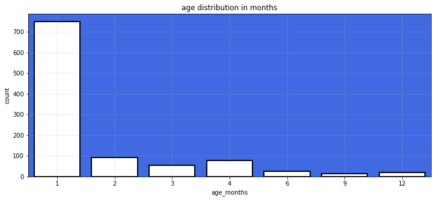

```python
plt.figure(figsize=(12,5))
order = [1, 2, 3, 4, 6, 9, 12]
ax = sns.countplot(new_concrete["age_months"],
                   order=order,linewidth=2,
                   edgecolor = "k"*len(order),
                   palette=["w"])
ax.set_facecolor("royalblue")
plt.title("age distribution in months")
plt.grid(True,alpha=.3)
plt.show()
```

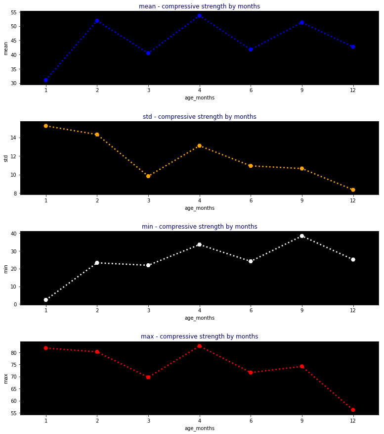

```python
age_mon = new_concrete.groupby("age_months")["strength"].describe().reset_index()

order  = [1, 2, 3, 4, 6, 9, 12]
cols   = [ 'mean', 'std' , 'min' , 'max']
length = len(cols)
cs     = ["b","orange","white","r"]

fig = plt.figure(figsize=(13,15))

for i,j,k in itertools.zip_longest(cols,range(length),cs):
    plt.subplot(4,1,j+1)
    ax = sns.pointplot("age_months",i,data = age_mon,
                       order=order,
                       markers="H",
                       linestyles="dotted",color=k)
    plt.subplots_adjust(hspace=.5)
    ax.set_facecolor("k")
    plt.title(i+" - compressive strength by months",color="navy")
```

#### Creating a Composite Feature from Cement and Water: cement water ratio.

```python
comp_concrete = new_concrete.copy()
comp_concrete['cementWaterRatio'] = comp_concrete.cement / comp_concrete.water
comp_concrete.head()
```

|  | cement | slag | ash | water | superplastic | coarseagg | fineagg | age | strength | age_months | cementWaterRatio |
| --- | --- | --- | --- | --- | --- | --- | --- | --- | --- | --- | --- |
| 0 | 141.3 | 212.0 | 0.0 | 203.5 | 0.0 | 971.8 | 748.5 | 28 | 29.89 | 1 | 0.694349 |
| 1 | 168.9 | 42.2 | 124.3 | 158.3 | 10.8 | 1080.8 | 796.2 | 14 | 23.51 | 1 | 1.066961 |
| 2 | 250.0 | 0.0 | 95.7 | 187.4 | 5.5 | 956.9 | 861.2 | 28 | 29.22 | 1 | 1.334045 |
| 3 | 266.0 | 114.0 | 0.0 | 228.0 | 0.0 | 932.0 | 670.0 | 28 | 45.85 | 1 | 1.166667 |
| 4 | 154.8 | 183.4 | 0.0 | 193.3 | 9.1 | 1047.4 | 696.7 | 28 | 18.29 | 1 | 0.800828 |

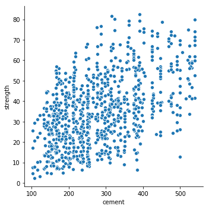

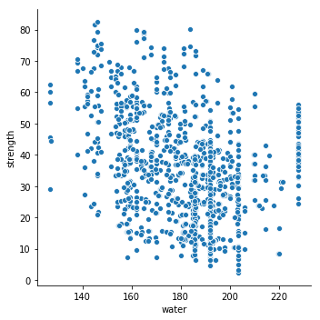

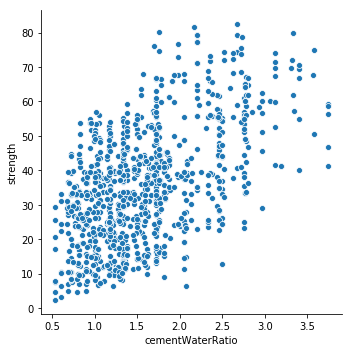

```python
sns.relplot( x = "cement", y = "strength", data = comp_concrete)
sns.relplot( x = "water", y = "strength", data = comp_concrete)
sns.relplot( x = "cementWaterRatio", y = "strength", data = comp_concrete)
```

##### Creating Composite Feature of similar aggregates i.e. coarseagg and fineagg

```python
comp_concrete['grainAggerate'] = (comp_concrete.coarseagg + comp_concrete.fineagg) / 2
```

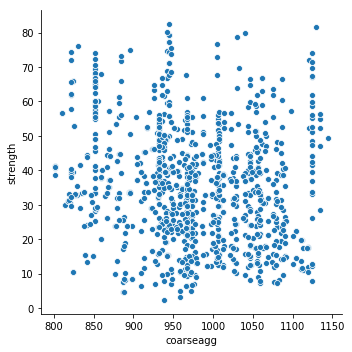

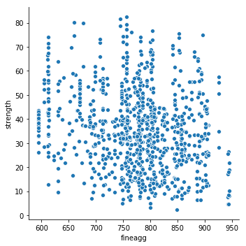

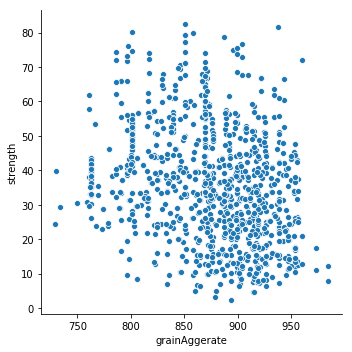

```python
sns.relplot( x = "coarseagg", y = "strength", data = comp_concrete)
sns.relplot( x = "fineagg", y = "strength", data = comp_concrete)
sns.relplot( x = "grainAggerate", y = "strength", data = comp_concrete)
```

#### Dropping fineagg and coarseagg features

```python
comp_concrete.drop(['fineagg', 'coarseagg'], axis = 1, inplace = True)
```

```python
features = comp_concrete.drop(['strength'], axis = 1)
X_scaled = features.apply(zscore)
```

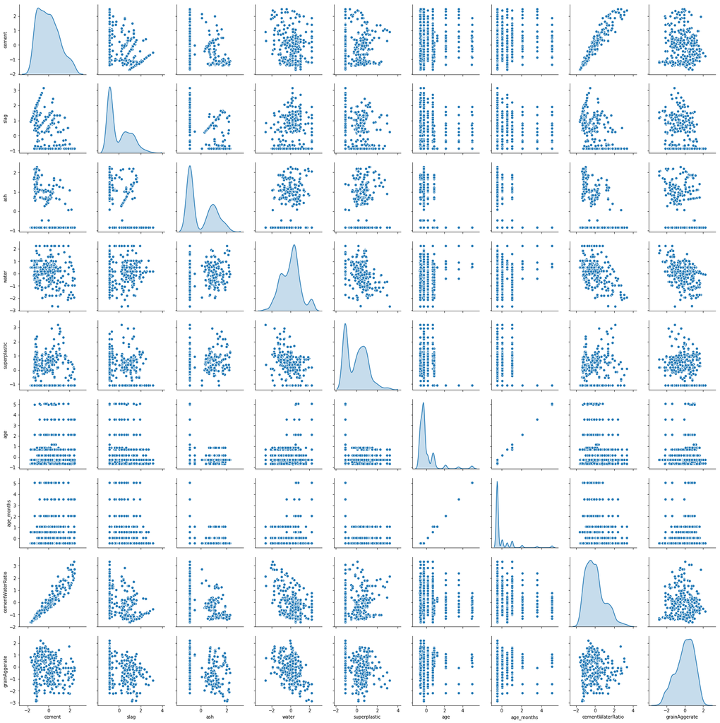

```python
#Visually inspect the covariance between dimensions

sns.pairplot(X_scaled, diag_kind='kde')
```

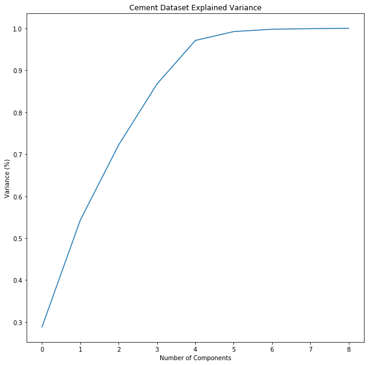

```python
from sklearn.decomposition import PCA
pca = PCA().fit(X_scaled)
#Plotting the Cumulative Summation of the Explained Variance
plt.figure(figsize=(10, 10))
plt.plot(np.cumsum(pca.explained_variance_ratio_))
plt.xlabel('Number of Components')
plt.ylabel('Variance (%)') #for each component
plt.title('Cement Dataset Explained Variance')
plt.show()
```

###### It makes sense, we’ll not use 100% of our variance, because it denotes all components, and we want only the principal ones.

```python
pca = PCA(n_components = 4, random_state = 1)
dataset = pca.fit_transform(X_scaled)
```

```python
print(pca.explained_variance_)
```

```
[2.5966088  2.29569029 1.61346539 1.30766419]
```

```python
print(pca.components_)
print('-----------------------------------------------------------------')
print(pca.explained_variance_ratio_)
```

```
[[ 0.10350962  0.10448437 -0.32564646  0.45566059 -0.39517403  0.4780396
   0.47176839 -0.04042966 -0.23624614]
 [ 0.62937932 -0.1906915  -0.22762362 -0.23673376  0.13919296  0.04717252
   0.06210308  0.65445479 -0.07678055]
 [-0.09820898 -0.5246157   0.32350887 -0.2044404   0.06527872  0.41135161
   0.423483   -0.04936543  0.46198835]
 [-0.07834175  0.38705204  0.30265993 -0.17450104  0.58935968  0.29175965
   0.27594689  0.00350662 -0.46192221]]
-----------------------------------------------------------------
[0.28823198 0.25482905 0.17909988 0.14515496]
```

```python
Xpca4 = pca.transform(X_scaled)
print(Xpca4)
```

```
[[ 0.99988635 -2.27447072 -1.62754363 -0.44008131]
 [-2.08797025 -1.13008426  1.19175628  0.12549766]
 [-0.66044973 -0.58996373  0.6803483  -0.74438932]
 ...
 [-0.47634686 -0.1516733  -0.80229055  0.98927721]
 [ 5.46758921  0.3733014   1.67489222  1.17556696]
 [ 0.10894704  3.37261626 -0.63725166 -1.6067836 ]]
```

```python
from sklearn.linear_model import LinearRegression
from sklearn.model_selection import train_test_split
```

```python
# Copy all the predictor variables into X dataframe. And 'strength' is dependent variable so storing it in y
X = Xpca4
y = comp_concrete['strength']
```

```python
# Split X and y into training and test set in 70:30 ratio

X_train, X_test, y_train, y_test = train_test_split(X, y, test_size=0.30, random_state = 1)
```

```python
#We will save the model performance metrics in a DataFrame
from sklearn.metrics import mean_squared_error, r2_score
from sklearn.model_selection import KFold, cross_val_score
import numpy as np
Model = []
RMSE = []
R_sq = []
cv = KFold(5, random_state = 1)

#Creating a Function to append the cross validation scores of the algorithms
def input_scores(name, model, x, y):
    Model.append(name)
    RMSE.append(np.sqrt((-1) * cross_val_score(model, x, y, cv=cv,
                                               scoring='neg_mean_squared_error').mean()))
    R_sq.append(cross_val_score(model, x, y, cv=cv, scoring='r2').mean())
```

```python
from sklearn.preprocessing import PolynomialFeatures
from sklearn.pipeline import make_pipeline
from sklearn.linear_model import LinearRegression, Ridge, Lasso
from sklearn.neighbors import KNeighborsRegressor
from sklearn.tree import DecisionTreeRegressor
from sklearn.ensemble import (RandomForestRegressor, GradientBoostingRegressor, AdaBoostRegressor)

names = ['Linear Regression', 'Ridge Regression', 'Lasso Regression',
         'K Neighbors Regressor', 'Decision Tree Regressor',
         'Random Forest Regressor', 'Gradient Boosting Regressor',
         'Adaboost Regressor']
models = [LinearRegression(), Ridge(), Lasso(),
          KNeighborsRegressor(), DecisionTreeRegressor(),
          RandomForestRegressor(), GradientBoostingRegressor(),
          AdaBoostRegressor()]

#Running all algorithms
for name, model in zip(names, models):
    input_scores(name, model, X_train, y_train)
```

```python
evaluation = pd.DataFrame({'Model': Model,
                           'RMSE': RMSE,
                           'R Squared': R_sq})
print("FOLLOWING ARE THE TRAINING SCORES: ")
evaluation
```

```
FOLLOWING ARE THE TRAINING SCORES:
```

|  | Model | RMSE | R Squared |
| --- | --- | --- | --- |
| 0 | Linear Regression | 11.163785 | 0.543160 |
| 1 | Ridge Regression | 11.163733 | 0.543170 |
| 2 | Lasso Regression | 11.218345 | 0.539388 |
| 3 | K Neighbors Regressor | 9.775988 | 0.650136 |
| 4 | Decision Tree Regressor | 12.024981 | 0.476277 |
| 5 | Random Forest Regressor | 9.429717 | 0.665151 |
| 6 | Gradient Boosting Regressor | 9.435363 | 0.674761 |
| 7 | Adaboost Regressor | 10.694386 | 0.584509 |

```python
Random Forest Regressor and Gradient Boosting Regressor Performed better than others.
```

```python
# Evaluating Linear Regression with Poly Features with Degree 2
pf = PolynomialFeatures(degree = 2 )
lr = LinearRegression()

lr.fit((pf.fit_transform(X_train)),y_train)
y_pred2  = lr.predict(pf.transform(X_test))

mse2 = mean_squared_error(y_test,y_pred2)
mae2 = mean_absolute_error(y_test,y_pred2)
r2_2 = r2_score(y_test,y_pred2)

print(mse2,mae2,r2_2)
```

```
95.34760519589283 7.597451553511955 0.6723895352174266
```

```python
# Evaluating Linear Regression with Poly Features with Degree 3
model = make_pipeline(PolynomialFeatures(3), LinearRegression())
model.fit(X_train, y_train)

rid_pred = model.predict(X_test)
rid_mse = mean_squared_error(y_test,rid_pred)
rid_mae = mean_absolute_error(y_test,y_pred2)
rid_r2_2 = r2_score(y_test,y_pred2)
print(rid_mse,rid_mae,rid_r2_2)
```

```
77.68766695041487 7.597451553511955 0.6723895352174266
```

```python
#Ridge to fix overfitting


model = make_pipeline(PolynomialFeatures(3), Ridge(alpha=0.002))
model.fit(X_train, y_train)

rid_pred = model.predict(X_test)
rid_mse = mean_squared_error(y_test,rid_pred)
rid_mae = mean_absolute_error(y_test,y_pred2)
rid_r2_2 = r2_score(y_test,y_pred2)
print(rid_mse,rid_mae,rid_r2_2)
```

```
77.68777631679622 7.597451553511955 0.6723895352174266
```

```python
#Lasso to fix overfitting
model = make_pipeline(PolynomialFeatures(3), Lasso(alpha=0.005))
model.fit(X_train, y_train)

lasso_pred = model.predict(X_test)
lasso_mse = mean_squared_error(y_test,lasso_pred)
lasso_mae = mean_absolute_error(y_test,y_pred2)
lasso_r2_2 = r2_score(y_test,y_pred2)
print(lasso_mse,lasso_mae,lasso_r2_2)
```

```
77.69488497451223 7.597451553511955 0.6723895352174266
```

##### Hypertuning Parameters:

```python
# creating train test validation splits:
X = Xpca4
y = comp_concrete['strength']
X_train, X_test, y_train, y_test = train_test_split(
    X, y, test_size = 0.3, random_state = 1)
```

```python
from pprint import pprint
RForest = RandomForestRegressor()
DTree.fit(X_train, y_train)


# Number of trees in random forest
n_estimators = [int(x) for x in np.linspace(start = 20, stop = 200, num = 5)]
# Number of features to consider at every split
max_features = ['auto', 'sqrt']
# Maximum number of levels in tree
max_depth = [int(x) for x in np.linspace(1, 45, num = 3)]
# Minimum number of samples required to split a node
min_samples_split = [5, 10]

# Create the random grid
random_grid = {'max_features': max_features,
               'max_depth': max_depth,
               'min_samples_split': min_samples_split}
pprint(random_grid)
```

```
{'max_depth': [1, 23, 45],
 'max_features': ['auto', 'sqrt'],
 'min_samples_split': [5, 10]}
```

```python
# Use the random grid to search for best hyperparameters

# Random search of parameters, using 3 fold cross validation,

rf_random = RandomizedSearchCV(estimator = RForest, param_distributions = random_grid)
# Fit the random search model
rf_random.fit(X_train, y_train)
```

```
RandomizedSearchCV(cv='warn', error_score='raise-deprecating',
          estimator=RandomForestRegressor(bootstrap=True, criterion='mse', max_depth=None,
           max_features='auto', max_leaf_nodes=None,
           min_impurity_decrease=0.0, min_impurity_split=None,
           min_samples_leaf=1, min_samples_split=2,
           min_weight_fraction_leaf=0.0, n_estimators='warn', n_jobs=None,
           oob_score=False, random_state=None, verbose=0, warm_start=False),
          fit_params=None, iid='warn', n_iter=10, n_jobs=None,
          param_distributions={'max_features': ['auto', 'sqrt'], 'max_depth': [1, 23, 45], 'min_samples_split': [5, 10]},
          pre_dispatch='2*n_jobs', random_state=None, refit=True,
          return_train_score='warn', scoring=None, verbose=0)
```

```python
tuning_pred = rf_random.predict(X_test)
```

```python
rdCVScore = r2_score(y_test, tuning_pred)
print(rdCVScore)
```

```
0.6936079762123238
```